## **Mountain pygmy possum**

### Blamed on cats

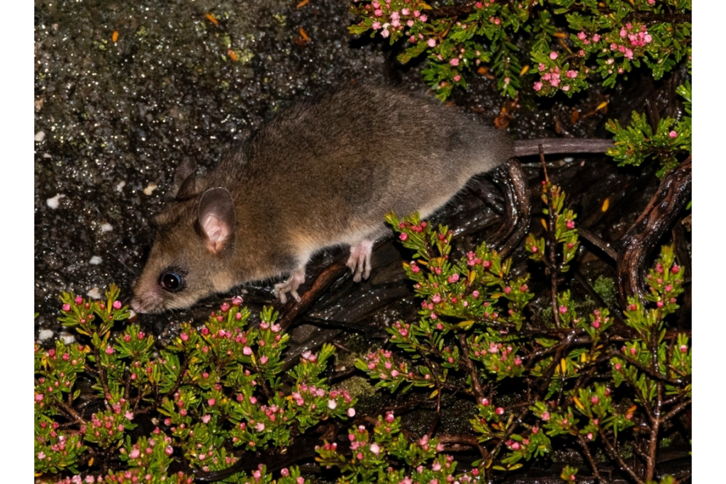

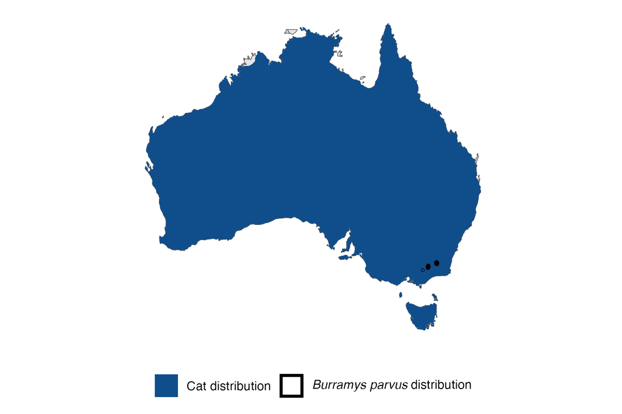

IUCN status: **Critically Endangered**

EPBC Predator Threat Rating: **Very high**

IUCN claim: *“The population at Mt. Buller suffers from fragmentation and subpopulations here and around ski resorts in the Kosciuszko area have declined severely since 2000 due to: habitat destruction, predation by feral cats, and possibly low snow cover.”*

### Studies not in support

No studies

### Is the threat claim evidence-based?

No studies were found linking cats to pygmy possum population trends.

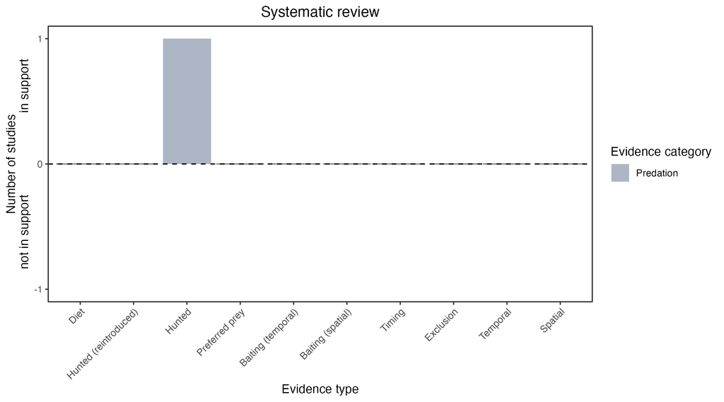

**Evidence linking *Burramys parvus* to cats.** Systematic review of evidence for an association between *Burramys parvus* and cats. Positive studies are in support of the hypothesis that *cats* contribute to the decline of Burramys parvus, negative studies are not in support. Predation studies include studies documenting hunting or scavenging; baiting studies are associations between poison baiting and threatened mammal abundance where information on predator abundance is not provided; population studies are associations between threatened mammal and predator abundance. Gold borders indicate studies that meet qualities of scientific rigour. See methods section in Wallach and Lundgren 2025 for details on evidence categories.

### References

Doherty, T.S., Davis, R.A., van Etten, E.J., Algar, D., Collier, N., Dickman, C.R., Edwards, G., Masters, P., Palmer, R. and Robinson, S., 2015. A continental‐scale analysis of feral cat diet in Australia. Journal of Biogeography, 42(5), pp.964-975.

EPBC. (2015) Threat Abatement Plan for Predation by Feral Cats. Environment Protection and Biodiversity Conservation Act 1999, Department of Environment, Government of Australia. (Table A1).

IUCN Red List. https://www.iucnredlist.org/ Accessed June 2023

Wallach A.D., Lundgren E.J. (2025) Review of evidence that foxes and cats cause extinctions of Australia’s endemic mammals. BioScience. DOI: 10.1093/biosci/biaf046